# Industry Visit

Johan Chinelle R. de Guzman, Ezekiel M. Racinez

11/28/2017

MEDTECS

I. Background and Processes

Medtecs International Corporation Limited is a company which provides a wide range of medical supplies but they focus more on uniforms and hospital linens. They are the leading manufacturer and distributor of healthcare products. Its factories are located in 3 different countries, Philippines, China and Cambodia. It also provides hospitals that serves Taiwan and the Philippines. Its primary services are rental of linens, management of laundry facilities and other hospital functions. It has served 49 hospitals for both Taiwan and the Philippines.

The different products are provided by the company are anti-static surgical attire, sterilized procedure tray products, Underpad and adult diapers, patient apparel, flame-retardant fabrics, surgical drapes, medical bandages, disposable surgical masks, boot covers and surgical gowns, crochet blankets and linens, n88 and n95 facemasks and many more medical supplies you could think of is what Medtecs provide for different hospitals served.

Medtecs Philippines started in the year 1989. The hospitals that are customers of the company in the Philippines are Allied Care Experts Medical Center, Calamba Medical Center, Clinica Antipolo Hospital and Wellness Center, De Los Santos Medical Center, Dr. Amando L. Garcia Medical Center, Inc., Emilio Aguinaldo Medical Center-Cavite, Lucena United Doctors Hospital and Medical Center, Our Lady of Mt. Carmel Medical Center, Navotas City Hospital, Nephro Group Dialysis Centers, United Hospital Builders Inc.-Paranaque Doctor’s Hospital, Perpetual Help Medical Center-Binan Laguna, Sacred Heart Medical Center and, Saint Jude Collge.

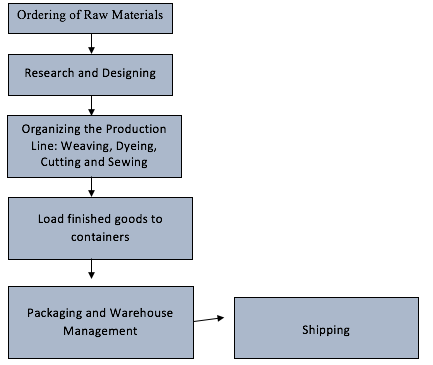

Process

The value chain of Medtecs may be similar to some manufacturing companies but its management of its final goods and packaging is what makes it unique. The ordering of raw materials includes the threads which come from different parts of Asia like Taiwan, Korea, China etc… These thread is transformed into fabric or textile for the achievement of the final product. Before production, a group of professionals would think of different designs that will meet the demands of the company’s clients. After designs are finalized then it will be sent to the production line in order to do the different processes of production which are weaving, dyeing, cutting and, sewing. If all of these processes are done, then it will be loaded in a container which corresponds to the finished goods done for that day. It is then sent to the packaging and warehouse management wherein they finalize where the different fabrics are to be sent and which fabrics are not at the standard. After everything, it is now ready for shipment to the different clients who ordered for the fabrics.

Processes:

Medtecs Hospital Linens Laundry Service Process Flow:

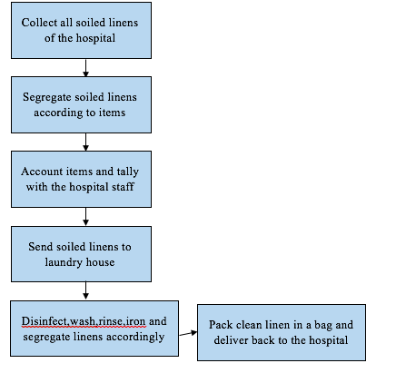

Process

These process flow represents what happens if a laundry service is availed by a certain hospital client. They usually let Medtecs do the laundry service because they think it is cost less for them. The hospital staff will collect all dirty linens and will segregate. Both the workers of Medtecs and Hospital Staff will account if how much and tally how many. Then if tallying and accounting is done, it will be sent to the laundry house. The linens will be disinfected, washed, rinsed,ironed and after doing so, it will be segregated again. After the laundry procedure then it will be packed clean in a bag and delivered back to the hospital client.

Medtecs Textile Production:

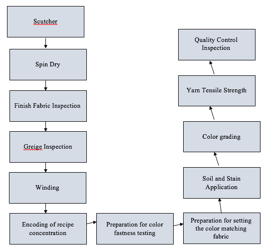

Process

The Medtecs Textile Production starts with the process in the equipment scutcher. The scutcher’s role is to spread out the fabric in preparation for heat setting process. Then it will go through the spindry process that will remove the excess. After spindrying, they will check the fabric. Then it will go through a greige inspection, to check if it is still in an undyed state. Then it goes through winding. They also test the quality of the fabric through encoding of recipe concentration, preparation for color fastness testing,preparation for setting the color matching fabric, soiil and stain application, color grading and, yarn Tensile Strength. The last step is the final quality control inspection.

Dyeing Process:

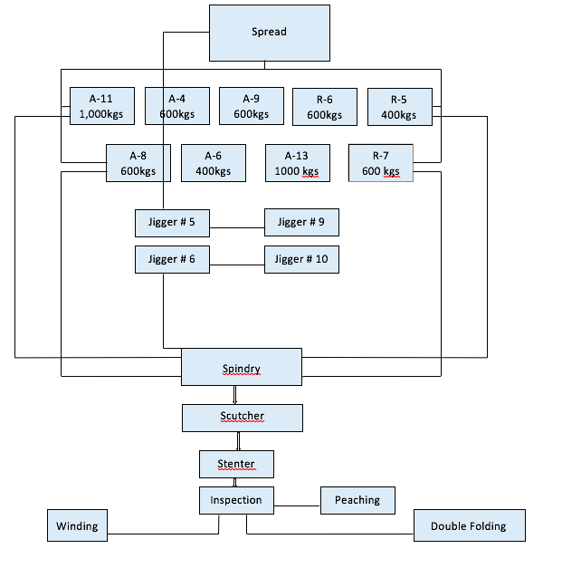

Process

The process flowchart above shows the process of dyeing for some fabrics in the company.It starts with the spread, which is a preparation process to distribute in each overflow or jigger machine. An overflow is used for bleaching, disperse dyeing and reactive dyeing while a jigger machine is used for cotton side vat dyeing process, which is for any 100 percent cotton fabric. Then after these processes, it goes through the spin dry which is done to remove the excessive fabric. Then it goes through the scutcher, which spread out the fabric in preparation for heat setting process. Then it will go through the stenter stage which is the process of drying and heat setting. Then, it will go through inspection which includes peaching, which makes the fabric smoother. Lastly, it will go through winding and double folding. Winding is for long fold while double folding is for double fold.

Weaving Process:

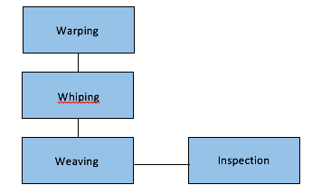

Process

The process of weaving starts with warping. In warping it separates the thread into different sizes. Then it goes through whipping wherein, it is manually segregated through in other for it to be easier for the machine to make a fabric. Then the weaving section happens wherein it is now being sown to make a certain fabric. Lastly, it is inspected if it is now ready to go through the other steps of production.

Equipment:

The different equipment they have are the spin dryer, overflow machines, jigsaw machines, warping machines, whipping machines, weaving machines, inspection machines, scutcher, stenter and many more machines that help in the production of fabrics. The cost of these equipment may vary since its sizes and jobs are different but it has estimated cost of around 10 million for all the equipment. The maintenance of these equipment was not that specified during the tour but as we were roaming around the facility, we were able to locate many maintenance documents on to when they clean and change the machines when it has already depreciated.

Human Capital Requirements:

In terms of human capital, the process starts with the vacancy of the job wherein Medtecs has an open position for a specific job either in production or administration. Then the company will develop on to what description or what type of job. After doing so, the company will post the schedule of recruitment which is called the recruitment plan. Then the manager for human resources will ask people from the company to help him or her in the search for new employees. After that the recruitment of new employees starts, then if it ends and they have selected people who are capable of the job then an series of interviews are made. The last straw of the recruitment would be the hiring and finalizing the job for the selected employee.

Medtecs are advocated in ensuring that their employees would perform at their best always. That is why they really consider them doing technical, vocational and training courses that will help them to become productive in the workplace.

The Board of Directors of Medtecs International:

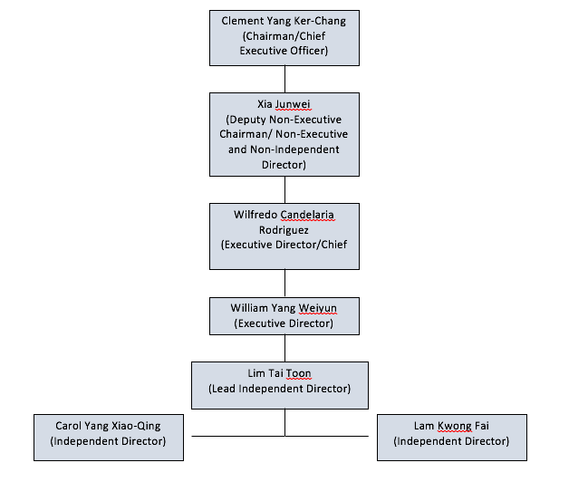

Process

The Chairman of the Medtecs company is responsible for the overall management of the company. He also responsible for the planning of strategies and development of products and services in the business. The Deputy Non-Executive Chairman of the company is responsible in helping the chairman in different business decisions and management but is not an employee of the company, they are their so that biases won’t happen in a company. The Executive Directors are helping the chairman as well in the management but with a help of marketing, fundraising and other ways to make the business successful. The Lead Independent Director is responsible for presiding a meeting when the chairman is not around, helps in relying info to the other members of the board and, accepts consultation. Lastly, the Independent Directors are people who does not have a relationship with the company and other members of the board which is effective for a non bias decision in certain situations.

FCF MANUFACTURNG CORPORATION (COACH):

1. BACKGROUND AND PROCESSES

FCF Manufacturing Corporation is a manufacturer of high quality bags which exports to Asia, USA, Europe and other places. One bag that FCF manufactures is the brand Coach. Coach started at the year 1941, where they focused on leather goods and accessories. Now, it is known worldwide with over 1000 stores. Up to this day, it still provides leather goods but now with bags, footwear, ready-to-wear, outerwear, accessories and many more. They believe they have a distinctive brand which has a New York and American style element. They believe as well that they are the leading choice for the market. They believe they have loyal customers who value their products so much. They believe as well that they have a wide range of distribution channels, they could be found in owned stores, online and other boutiques. Lastly, they do believe in their customers, they are open to suggestions.

FCF Manufacturing was chosen by Coach since it caters a lot of luxury bags as well such as Michael Kors, Kate Spade but Coach is unique from them since it has its own factory and its processes are stricter. It is said that FCF does not cater students who wants to visit the factory and this year was the only year that they did these because they believe that the local community should know what the Filipino factory workers do to produce the luxury bags.

In their everyday operations, the longest hours the workers work is 12 hours and the amount of per line products ranges from 200-300, for all bags it will result 12,000-15,000 a day. Manpower skills is believed to become a huge problem which results to many rejects. The rejects may vary and are debranded at once.

FCF MANUFACTURING CORPORATION Value Chain:

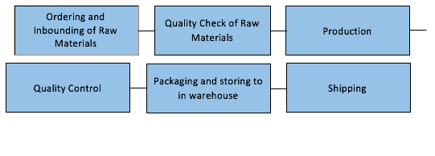

Process

The value chain of FCF Manufacturing starts off with the ordering of raw materials and inbounding them in their raw materials warehouse. The company orders the leather which Coach requests which may come from different parts of Europe especially Italy. Next, it will go through quality check, if the leather is not in good shape then the leather will not be used and it will be eliminated by the company. Then if the raw materials is at its standard then it will go though a series of steps in the production process itself. The production process is the longest step in the value chain since it is when the proposed product comes to physical shape. After all the production steps, it will go through quality control wherein a group of workers would check and identify which products are accepted and rejected, but in the production steps there are products already accepted and rejected especially if it is already near its end of production. Packaging is then done, by putting them in various boxes with the same product line and marking them on to which country is it to be sent, either Jacksonville, Japan, China and, Europe. The last step of the value chain would be shipping it to the client which is the Company, Coach.

FCF MANUFACTURING CORPORATION (COACH PRODUCTION PROCESS):

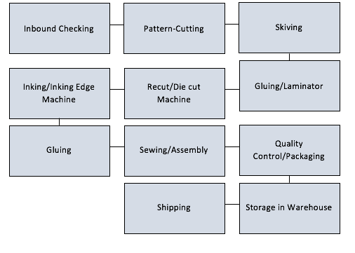

Process

The production process of Coach starts off with the checking of received raw materials. It is important for the inbounded materials to be in good quality. It is always Coach’s choice if the materials are at its standard. The warehouse for leather is 65 degrees below so that the leather won’t be damaged. Next is when the supplies are now being produced. It starts with the pattern cutting wherein the workers create patterns which makes the bag in that specific product line. Skiving is then done to reduce the thickness of the leather. The next process would be Gluing by the laminator; the job of the glue laminator is to attach large components of leather. Next is the re-cutting stage where a finalize cut is to be done. Then it will continue its process by inking which uses the inking edge machines, this machine is a rolling machine with ink that is painting the edges to hide the stitches and seal the edges of the bags and straps. It will go through gluing again for it to become more durable for sewing. Sewing and assembly of the bag is then done by workers and machines. Workers hand sown the handles and the other parts are sown by the machine. When the bags are done, there are specialized workers who check the total quality of the product then there are also workers who do the packaging of the product. After the packaging, the boxes are labeled to which country it is to be sent and it is stored in the warehouse. When the orders are due and are ready for shipment, then it is now time for shipment.

Equipment:

The different equipment that FCF Manufacturing has are the cutting machine, glue laminator, die cut machine, inking edge machine and many more. They are only a a few machines because mostly their products are done manually. The costing of these machines are not specified by the company but may range around half a million. The maintenance as well is not that specified but there is a supervisor for each section to check the machines and how the workers produce the product.

Human Capital Requirements:

The totality of workers in the FCF Manufacturing Corporation is more than 5,000. Today, there are a lot of job openings for the company. There was a job opening last august 1 2017 of Impex Staff and IQC. Impex Staff who are male/female, 18 years old and above, college degree holder, who knows in Microsoft Office and is a fast learner. For the IQC, male/female, 18 years old and above, college level and has experience. The closing for that recruitment was last August 31,2017. Then there was an opening last July 12, 2017 for table workers, warehouse manager, industrial engineer, pattern maker, executive assistant, Junior Merchandiser, Senior Merchandiser, Sewer and, Trainee Sewer. A total of 361 job openings for the month which ended August 12,2017. For May 16,2017, a job opening of electricians which are a total of 5 and it ended May 31, 2017. For April 17, 2017, a job opening for a logistic manager which has no closing day up to this day and for February 6, 2016, a job opening of cutting operations, high head machine operator, quality controller, table works, skilled sewer. A total of 1,120 job opportunities up to this date since there is still no closing date.

GUANGQIANG:

Guangqiang Manufacturing Corp., is a manufacturer of professional quality of steel mold and raw material for bags like Kate Spade, Coach, Michael Kors, and other known luxury products that is being made in the Philippines. They also make molds for some shoe factories in the Philippines. The manufacturing company produces raw materials like bonded leather, fiber paper, fitted material, non-woven fabric, polyester lining, bontex, and etc. I asked their supervisor on how long they are running in that kind of manufacturing industry. As per the supervisor’s told me, they have been in the industry for more than 20 years. As we visited their industry, I myself can clearly see the dedication and sophistication of workers when it comes to doing their job. When it comes to their conformance in their products, they really follow and do their best to meet the standard of mold.

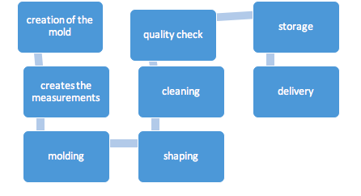

Process

As you can see in the process, the first process is the creation of the mold. The people who are responsible in creating the mold are the computer engineer. Second is, creating the measurement. In this process, the only thing they need to do is to put the exact measurements needed in order to comply with what the customer ordered or requested. Third process is molding, wherein they use the measurements from second process and the shape they created from first process, to be able to come up with the initial mold needed. Fourth process, the shaping. In this process, the workers will be welding an initial mold from the processes made prior. This is to comply with the shape, measurement, and design the customer asked for. Usually, these molds are for the bags, shoes, and foams. Fifth process is the cleaning process, wherein they refine the edges from rough to a fine one in order to meet the perfection of the mold. Additional process of the company after the five processes: Sixth, the quality check. After making the mold, the mold will undergo the quality check in order for the product to be accepted or rejected. After the quality check, here’s the Seventh process, the storage. Wherein the product will be put in a package and be stored in their storage warehouse before delivering it to the customers. The last and eighth process is the delivery. This time, the molds ordered by the customer will be delivered to shipping address. This process is the complete process of the manufacturing company. From the creation of the mold, to creating measurements, to molding, to shaping, to cleaning, to quality check, to storage, until delivery. All in all, there is 8 steps or process in the Guangqiang Manufacturing Corp. Human resource or the human power of the company is the company’s biggest asset. Since the company is in technical side, every detail must meet the certain standard of each process. In this case, the manpower of the company must be in huge numbers and everyone must be skilled and underwent technical trainings in order for the company to propagate and considered to be a company with great quality.

Some workers are the following positions: Metal Mould Bender, CNC Machine Operator, Auto CAD Operator, CNC/Lathe Machine Helper, Blade/Wire Cutting Operator, Welder, Translator (Chinese-English/Tagalog), AutoCAD Operator, Finishing Operator, Merchandiser, Lathe Operator, Electrician, Laser Machine Operator, Mould Bender/Welder. These are just some. So far, after visiting the company, I can see that what they needed the most is the Translator (Chinese-English/Tagalog).

The reason why it is what the company needed the most, it is because the owner of the company is Chinese and the company’s workers are all Filipinos. Meeting and talking with them is really hard because we cannot clearly understand with what the Chinese people are saying. Even though the conversation is an informative conversation, it will be useless and nonsense because one person to another cannot understand the exchanging of information.

As for the qualifications of the job positions in the company of the Guangqiang Manufacturing Corp., all of them requires the potential worker to be 18 years old and above. But here are their different qualifications. For the Metal Mould Bender, it requires to be a female. CNC Machine Operator, it requires to be a male and be at least a college graduate of any degree. The requirements with CNC Machine Operator is same with Auto CAD Operator. The CNC/Lathe Machine Helper, it can be a male or female. The Blade/Wire Cutting Operator, it must be male that have experienced to work from 6 months-1 year. The Welder, it must be male that finished any vocational course. It must also experienced working at least 6 months. The Translator (Chinese-English/Tagalog), of course this must know how to speak, write, and read fluent Chinese, Filipino, and English. This must be male only that at least reached the college level with 1 up to 2 years experienced in doing a relevant job. The AutoCAD Operator, this must be at least reached the college level and must be in the field of AutoCAD. This must be skillful in doing the AutoCAD-ing and must have 1-2 years of experience in this kind of job field. The Finishing Operator. The Finishing Operator must be a male. The Merchandiser, this can be female or male. This must be a college graduate and the most important requirement for this position is that, this person should know how to speak Chinese and English and/or Chinese and Tagalog. The Lathe Operator, this must be male. This must be a college graduate with relevant working experience of 6 months to 1 year. This must also know how to operate the Lathe Machine itself. The Electrician. An Electrician for this company must be a college graduate under the field of Electrical Engineering. This must also be a male, of course, and must have a real working experience of 1-2 years. The Laser Machine Operator, this can be with working experience or none at all. As long as it is a male and have reached the age of 18 years old; and lastly, the Mould Bender/Welder. With this job position, they need to be at least 18 years old. They can have with job experience or without job experience. The Mould Bender/Welder and the Laser Machine Operator job positions just have the same qualifications and have the same standards before being hired and undergo some trainings.

References:

About Us. (n.d.). Retrieved from http://www.medtecs.com

About Us. (n.d.). Retrieved from https://medtecs-ph.com

Recruitment & Selection Hiring Process. (n.d.). Retrieved from https://hr.ucr.edu/recruitment/guidelines/process.html

Corporate Directory. (n.d.). Retrieved from http://www.medtecs.com/Med_2015_EN.pdf

Non-executive director. (n.d.). Retrieved from https://en.wikipedia.org/wiki/Non-executive_director

Independent director. (n.d.). Retrieved from https://en.wikipedia.org/wiki/Independent _director

Working at Fcf manufacturing corporation company profile and information. (n.d.). Retrieved from https://www.jobstreet.com.ph/en/companies/987396-fcf-manufacturing- corporation

About Coach. (n.d.). Retrieved from http://world.coach.com/careers-about-coach.html

AFAB Job Openings. (n.d.). Retrieved from http://afab.gov.ph/?page_id=821

Job Opportunities . (n.d.). Retrieved from http://www.afablabor.com/job-opportunities

FCF MANUFACTURING CORP. (n.d.). Retrieved from http://www.afablabor.com/job-opportunities/category/fcf-manufacturing-corp

Managing the Production Process in a Manufacturing Company. (n.d.). Retrieved from https://2012books.lardbucket.org/books/an-introduction-to-business-v2.0/s15-03-managing -the-production-proces.html

Manufacturing Business Processes. (n.d.). Retrieved from https://www.prevas.com/manufacturing_business_processes.html

GUANGQIANG MANUFACTURING CORPORATION. (n.d.). Retrieved from http://www.afablabor.com/job-opportunities/category/guangqiang-manufacturing-corporation

Guangqiang Manufacturing Corp. (n.d.). Retrieved from http://en.52wmb.com/buyer/25821107

What is Human Resource Management? (November 1, 2017) Retrieved November 27, 2017, from https://www.thebalance.com/what-is-human-resource-management-1918143

(n.d.). Retrieved January 25, 2001, from http://www.businessdictionary.com/definition/machine.html

(n.d.). Retrieved October 11, 2004, from http://www.managementstudyguide.com/job-design.htm

GUANGQIANG MANUFACTURING | Metal and Steel Manufacturing | 7th Street, Mariveles, Bataan. (n.d.). Retrieved November 27, 2017, from http://www.yellow-pages.ph/business/guangqiang-manufacturing-corporation

AUTHORITY OF THE FREEPORT AREA OF BATAAN. (n.d.). Retrieved November 27, 2017, from http://www.afablabor.com/